# Project Python Foundations: FoodHub Data Analysis

### **Question 7**: Which are the top 5 restaurants in terms of the number of orders received? [1 mark]

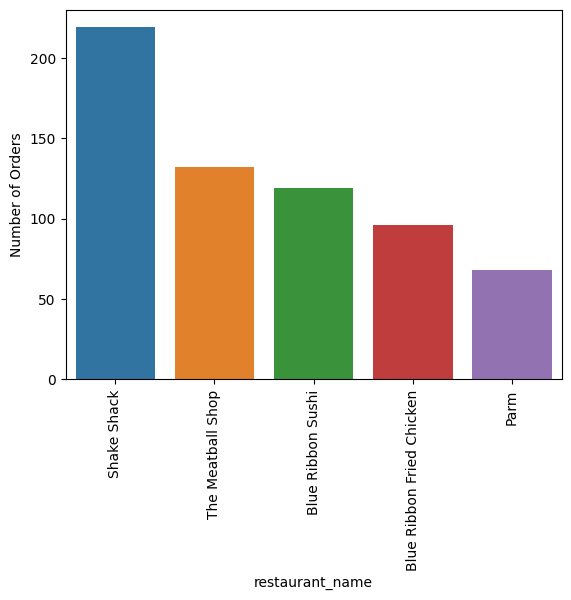

```python
sns.barplot(data=restaurantdf.head(5),x="restaurant_name",y="count")
plt.xticks(rotation=90)
plt.ylabel('Number of Orders')
```

#### Observations:

- *Top 5 restaurants in terms of order and restaurant "shake shack" has the highest number of orders*

### **Question 8**: Which is the most popular cuisine on weekends? [1 mark]

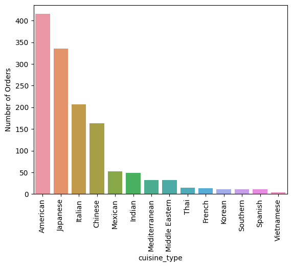

```python
weekendcuisinedata = df.loc[df['day_of_the_week'] == "Weekend"]
order = weekendcuisinedata["cuisine_type"].value_counts().index
sns.countplot(data=weekendcuisinedata,x="cuisine_type",order = order)
plt.xticks(rotation=90)
plt.ylabel('Number of Orders')
```

#### Observations:

*The American cuisine having the highest number of orders in the weekend.*

### **Question 9**: What percentage of the orders cost more than 20 dollars? [2 marks]

```
29.24130663856691
```

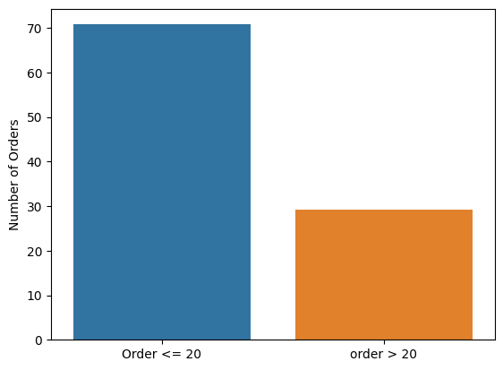

```python
expensiveorder = (len(df[df['cost_of_the_order'] > 20])/len(df))*100
print(expensiveorder)
sns.barplot(x=["Order <= 20","order > 20"],y=[100-expensiveorder,expensiveorder])
plt.ylabel('Number of Orders')
```

#### Observations:

- *29.24% of the orders cost more than 20 dollars*

### **Question 10**: What is the mean order delivery time? [1 mark]

```python
df.describe().T
```

|  | count | mean | std | min | 25% | 50% | 75% | max |
| --- | --- | --- | --- | --- | --- | --- | --- | --- |
| customer_id | 1898.00 | 171168.48 | 113698.14 | 1311.00 | 77787.75 | 128600.00 | 270525.00 | 405334.00 |
| cost_of_the_order | 1898.00 | 16.50 | 7.48 | 4.47 | 12.08 | 14.14 | 22.30 | 35.41 |
| food_preparation_time | 1898.00 | 27.37 | 4.63 | 20.00 | 23.00 | 27.00 | 31.00 | 35.00 |
| delivery_time | 1898.00 | 24.16 | 4.97 | 15.00 | 20.00 | 25.00 | 28.00 | 33.00 |
| Total_Time_Taken | 1898.00 | 51.53 | 6.83 | 35.00 | 47.00 | 52.00 | 56.00 | 68.00 |

```python
df["delivery_time"].mean()
```

```
24.161749209694417
```

### **Question 11:** The company has decided to give 20% discount vouchers to the top 3 most frequent customers. Find the IDs of these customers and the number of orders they placed. [1 mark]

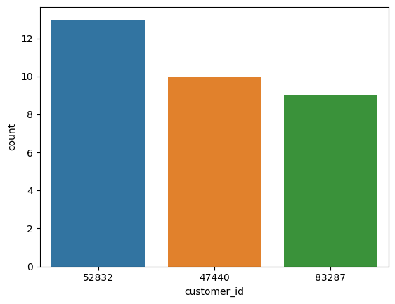

```python
sns.barplot(data=customerdf.head(3),x="customer_id",y="count",order = customerdf["customer_id"].head(3))
```

#### Observations:

- The customer "52832" have placed highest number of orders throught the app.

### **Question 12**: Perform a multivariate analysis to explore relationships between the important variables in the dataset. (It is a good idea to explore relations between numerical variables as well as relations between numerical and categorical variables) [10 marks]

**Correlation Map**

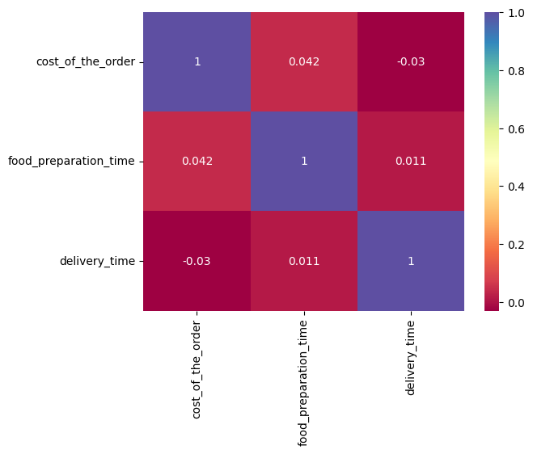

```python
# relationship between different numerical variables

sns.heatmap(data=df[['cost_of_the_order','food_preparation_time','delivery_time']].corr(),annot=True,cmap="Spectral")
```

- *From the correlation map, it is observed that there is no much correlation between cost of the order, food preparation time and the delivery time*

**cuisuine's that are more profitable to the company**

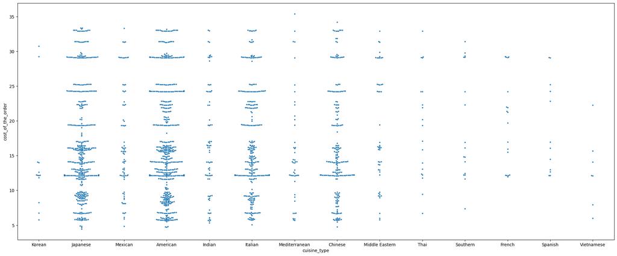

```python
plt.figure(figsize=(25,10))
sns.swarmplot(data=df, x='cuisine_type', y='cost_of_the_order',size=3);
```

- American, Japanese, Italian and Chinese provide more profit to the company rather than the other cuisine

**Days that are more profitable to the company**

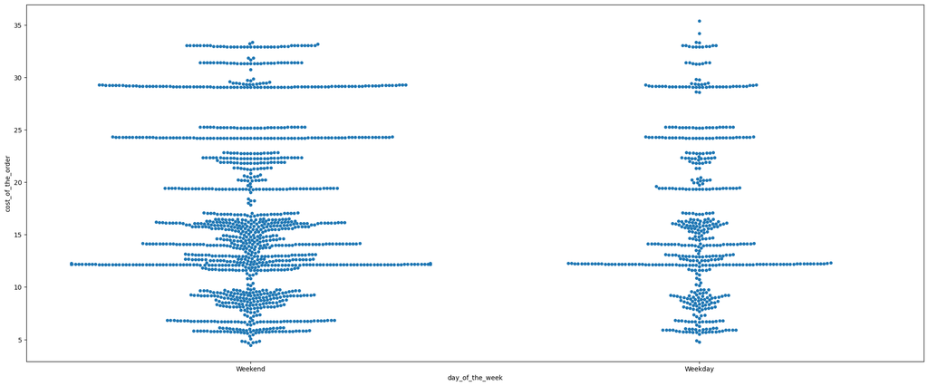

```python
plt.figure(figsize=(25,10))
sns.swarmplot(data=df, x='day_of_the_week', y='cost_of_the_order',size=5);
```

*Weekends orders are more profitable compared to the weekdays*

**Restaurants that are more profitable to the company**

```python
restaurantbycostdf = df.groupby(["restaurant_name"])["cost_of_the_order"].sum().sort_values(ascending=False).reset_index()
restaurantbycostdf
```

|  | restaurant_name | cost_of_the_order |
| --- | --- | --- |
| 0 | Shake Shack | 3579.53 |
| 1 | The Meatball Shop | 2145.21 |
| 2 | Blue Ribbon Sushi | 1903.95 |
| 3 | Blue Ribbon Fried Chicken | 1662.29 |
| 4 | Parm | 1112.76 |
| ... | ... | ... |
| 173 | Market Table | 6.79 |
| 174 | Wa Jeal | 6.74 |
| 175 | Cipriani Le Specialita | 5.92 |
| 176 | Big Wong Restaurant _¤¾Ñ¼ | 5.92 |
| 177 | Hunan Manor | 5.72 |

178 rows × 2 columns

```
([0, 1, 2, 3, 4, 5, 6, 7, 8, 9],
 [Text(0, 0, 'Shake Shack'),
```

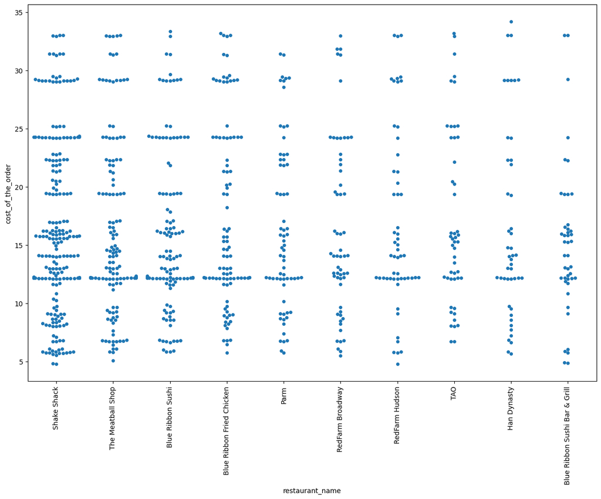

```python
plt.figure(figsize = (15,10))
sns.swarmplot(data=df[df['restaurant_name'].isin(restaurantbycostdf["restaurant_name"].head(10))], x='restaurant_name', y='cost_of_the_order',size=5,order=restaurantbycostdf["restaurant_name"].head(10));
plt.xticks(rotation=90)
```

- *Top 10 restaurants which renders more profit to the company.*
- *We can witness the orders in all the range(cost) and it is densily populated between 12 to 25 dollars*

**Restaurants that render least profit to the company**

```
([0, 1, 2, 3, 4, 5, 6, 7, 8, 9],
 [Text(0, 0, 'Gaia Italian Cafe'),
```

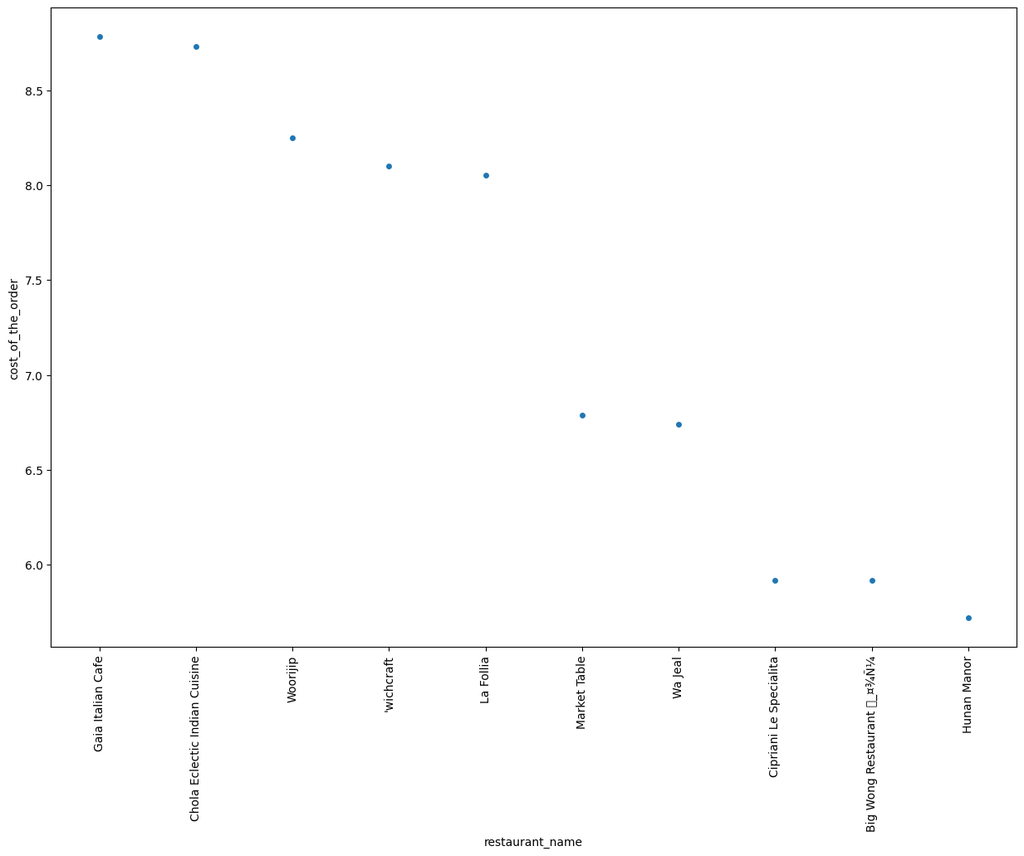

```python
plt.figure(figsize = (15,10))
sns.swarmplot(data=df[df['restaurant_name'].isin(restaurantbycostdf["restaurant_name"].tail(10))], x='restaurant_name', y='cost_of_the_order',size=5,order=restaurantbycostdf["restaurant_name"].tail(10));
plt.xticks(rotation=90)
```

- *10 restaurants which renders least profit to the company.*

**Relation between cost of the order and the rating:**

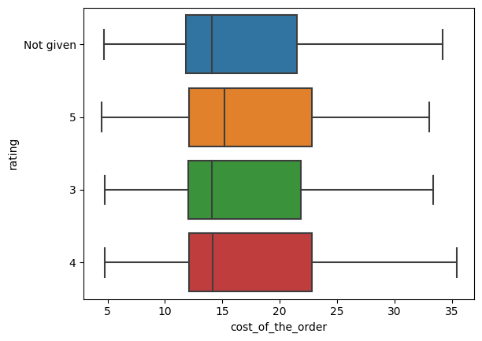

```python
sns.boxplot(data=df, x='cost_of_the_order',y='rating')
```

*From the graph, as the median of all the rating is almost same, there is no relation between the cost of the order and the rating.*

**Top 10 customers who has been more profitable to the company - customer spending trend.**

```
      customer_id  cost_of_the_order
116         52832             225.80
839        250494             183.83
84          47440             158.18
870        276192             146.46
333         83287             139.31
...           ...                ...
213         64754               5.34
1000       339144               5.05
960        318665               4.90
101         50123               4.85
603        133617               4.75

[1200 rows x 2 columns]
```

```
(array([0, 1, 2, 3, 4, 5, 6, 7, 8, 9]),
 [Text(0, 0, '52832'),
```

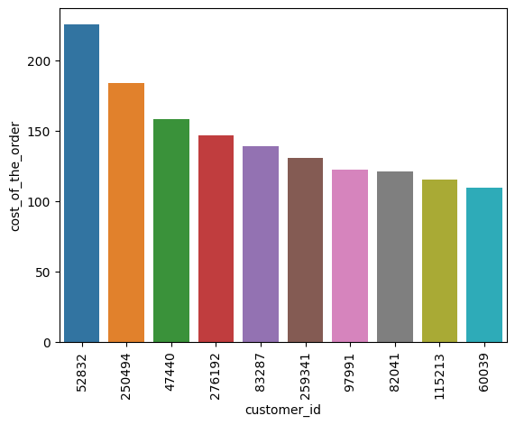

```python
customercostdf = df.groupby(["customer_id"])["cost_of_the_order"].sum().reset_index().sort_values(by=["cost_of_the_order"],ascending=False)
print(customercostdf)
sns.barplot(data = customercostdf.head(10),x="customer_id",y="cost_of_the_order", order=customercostdf['customer_id'].head(10))
plt.xticks(rotation=90)
```

**customers spending over the day_of_the_week**

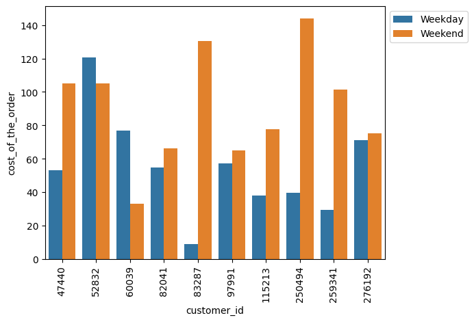

```python
customercostdaysdf = df.groupby(["customer_id","day_of_the_week"])["cost_of_the_order"].sum().reset_index()
top10cusomterlist = customercostdf["customer_id"].head(10)
sns.barplot(data = customercostdaysdf[customercostdaysdf["customer_id"].isin(top10cusomterlist)],x="customer_id",y="cost_of_the_order", hue="day_of_the_week")
plt.xticks(rotation=90)
plt.legend(bbox_to_anchor=(1, 1))
```

*Customers spend more over the weekends rather than the weekdays*

**Customers who has not rated even once and their number of orders**

```python
notratedcustomer = df.groupby(["customer_id","rating"])["rating"].count().reset_index(name='count')
notratedcustomer['total_count'] = notratedcustomer.groupby('customer_id')['count'].transform('sum')
notratedcustomerdf = notratedcustomer[(notratedcustomer['rating'] == 'Not given') & (notratedcustomer['count'] == notratedcustomer['total_count'])]
notratedcustomeralldf = df[df["customer_id"].isin(notratedcustomerdf["customer_id"])]
notratedcustomerordercount = notratedcustomeralldf["customer_id"].value_counts().reset_index()
notratedcustomerordercount = notratedcustomerordercount.rename(columns={'index': 'customer_id', 'customer_id': 'Order Count'})
notratedcustomerordercount
```

|  | customer_id | Order Count |
| --- | --- | --- |
| 0 | 115610 | 3 |
| 1 | 132906 | 3 |
| 2 | 49631 | 3 |
| 3 | 68551 | 3 |
| 4 | 300003 | 3 |
| ... | ... | ... |
| 336 | 41136 | 1 |
| 337 | 73873 | 1 |
| 338 | 283310 | 1 |
| 339 | 7567 | 1 |
| 340 | 97838 | 1 |

341 rows × 2 columns

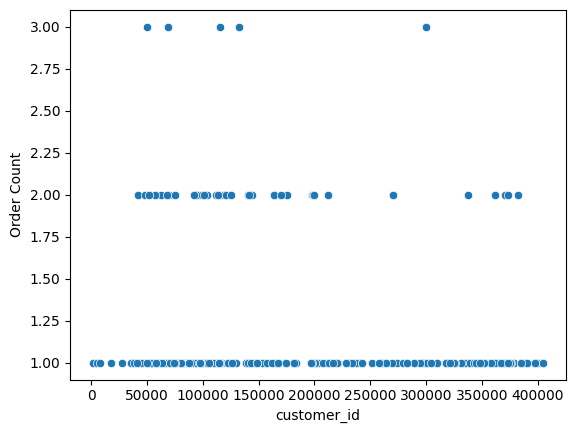

```python
sns.scatterplot(data=notratedcustomerordercount,x="customer_id",y="Order Count")
```

*There are totally 341 customers who has not rated even once and thier maximum number of orders is 3.*

**Percentage of customers who has not rated even once**

```python
(notratedcustomerordercount["customer_id"].nunique()/df["customer_id"].nunique()) * 100
```

```
28.416666666666668
```

*28% of the customers who has not even rated once*

**Restaurtants that has repeated orders for same customers**

```python
repeatedordersdf = df.groupby(["customer_id","restaurant_name"])["restaurant_name"].count().reset_index(name="count").sort_values(by=["count"],ascending=False)
```

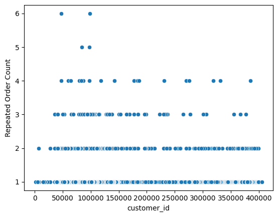

```python
sns.scatterplot(data=repeatedordersdf,x="customer_id",y="count")
plt.ylabel('Repeated Order Count')
```

*Compartively there is good frequency of orders with twice and thrice.*

**Restaurants that has not been rated even once and thier number of orders:**

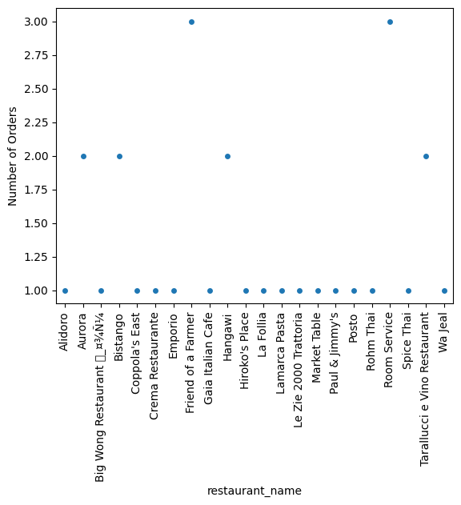

```python
notratedrestaurant = df.groupby(["restaurant_name","rating"])["rating"].count().reset_index(name='count')
notratedrestaurant['total_count'] = notratedrestaurant.groupby('restaurant_name')['count'].transform('sum')
notratedrestaurant[(notratedrestaurant['rating'] == 'Not given') & (notratedrestaurant['count'] == notratedrestaurant['total_count'])]

sns.swarmplot(data=notratedrestaurant[(notratedrestaurant['rating'] == 'Not given') & (notratedrestaurant['count'] == notratedrestaurant['total_count'])], x='restaurant_name', y='count',size=5);
plt.xticks(rotation=90)
plt.ylabel('Number of Orders')
```

*Restuarants that have not rated even once have only one few orders*

**Restaurants that are multi cuisine and thier number of orders**

```python
rescuisinedf = df.groupby(["restaurant_name"])["cuisine_type"].nunique().reset_index(name='cuisine_count')
rescuisinedmulticuisine = rescuisinedf[rescuisinedf["cuisine_count"] > 1]
multicuisinelist = list(rescuisinedmulticuisine["restaurant_name"])
print(rescuisinedmulticuisine)
```

```
       restaurant_name  cuisine_count
153  The Meatball Shop              2
```

*There is only one restaurant which is multi cuisine*

**Compare the number of orders, food preparation time and the delivery time between the single cuisine and the multi cuisine restaurtant.**

```python
# get the single cuisine restaurant's that has maximum number of orders
singlecuisinelist = df["restaurant_name"].value_counts().head(1)
singlecuisine = singlecuisinelist.index[0]
targetdf = df[df["restaurant_name"].isin([singlecuisine,multicuisinelist[0]])]
grouped_df = targetdf.groupby(['restaurant_name']).agg({
    'cost_of_the_order': 'sum',
    'food_preparation_time': 'mean',
    'delivery_time': 'mean'
}).reset_index()
grouped_df
```

|  | restaurant_name | cost_of_the_order | food_preparation_time | delivery_time |
| --- | --- | --- | --- | --- |
| 0 | Shake Shack | 3579.53 | 27.95 | 24.66 |
| 1 | The Meatball Shop | 2145.21 | 27.18 | 24.24 |

*There is no much difference in the food prepation time for a single cuisine and multi cuisine restaurant. Also, to be noted this multi cuisine restaurant is second in terms of order.*

**Does the Total Time taken affects the rating**

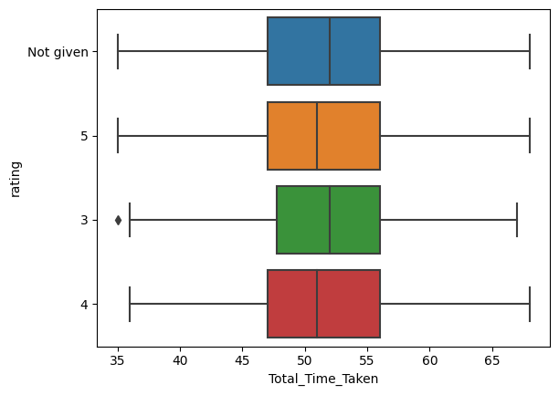

```python
sns.boxplot(data=df, x="Total_Time_Taken",y="rating")
```

*The restaurant that has rating 3 has an outlier as well.*

**Delivery time during the weekends and weekdays**

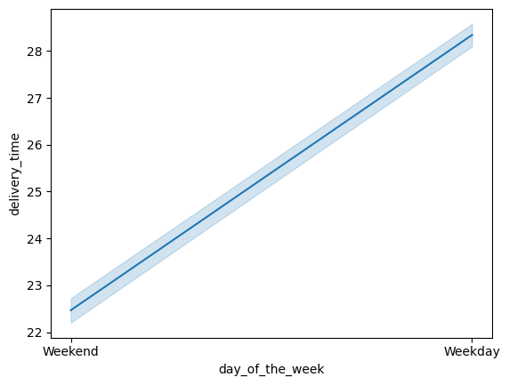

```python
sns.lineplot(data=df, x='day_of_the_week', y='delivery_time');
```

- *The average delivery time on weekend is lesser than the weekday might be because of traffic*

**Food preparation time during the weekends and weekdays**

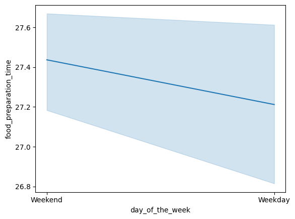

```python
sns.lineplot(data=df, x='day_of_the_week', y='food_preparation_time');
```

*The average food preparation time during the weekend is more than the weekdays might be because of number of orders are more during the weekend.*

**Restaurants taking less time for food preparation**

```
([0, 1, 2, 3, 4, 5, 6, 7, 8, 9, 10, 11, 12, 13, 14, 15, 16, 17, 18, 19],
 [Text(0, 0, 'Haru Gramercy Park'),
```

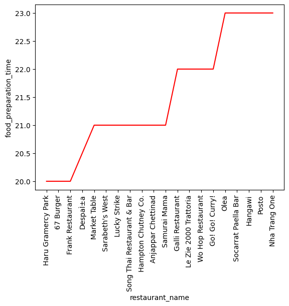

```python
fastestfoodpreparation = df.groupby(["restaurant_name","cuisine_type"])["food_preparation_time"].mean().reset_index().sort_values(by = "food_preparation_time",ascending = True)
sns.lineplot(data=fastestfoodpreparation.head(20), x="restaurant_name", y="food_preparation_time", ci=False, color="red")
plt.xticks(rotation=90)
```

**Restaurants that are delivering faster in terms of both food preparation and delivery time:**

```
([0, 1, 2, 3, 4, 5, 6, 7, 8, 9, 10, 11, 12, 13, 14, 15, 16, 17, 18, 19],
 [Text(0, 0, 'Wo Hop Restaurant'),
```

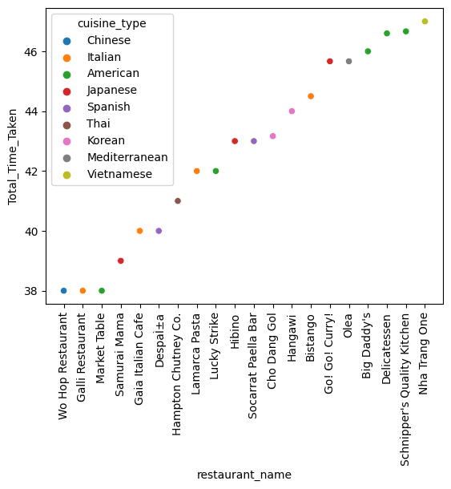

```python
fastestdelivery = df.groupby(["restaurant_name","cuisine_type"])["Total_Time_Taken"].mean().reset_index().sort_values(by = "Total_Time_Taken",ascending = True)
fastestdelivery
sns.scatterplot(data=fastestdelivery.head(20),x="restaurant_name",y="Total_Time_Taken",hue="cuisine_type");
plt.xticks(rotation=90)
```

**Cuisine's that are delivering faster in terms of both food preparation and delivery time?**

```
([0, 1, 2, 3, 4, 5, 6, 7, 8, 9, 10, 11, 12, 13],
 [Text(0, 0, 'Korean'),
```

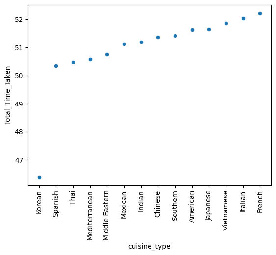

```python
fastestcuisinedelivery = df.groupby(["cuisine_type"])["Total_Time_Taken"].mean().reset_index().sort_values(by = "Total_Time_Taken",ascending = True)
sns.scatterplot(data=fastestcuisinedelivery.head(20),x="cuisine_type",y="Total_Time_Taken");
plt.xticks(rotation=90)
```

### **Question 13:** The company wants to provide a promotional offer in the advertisement of the restaurants. The condition to get the offer is that the restaurants must have a rating count of more than 50 and the average rating should be greater than 4. Find the restaurants fulfilling the criteria to get the promotional offer. [3 marks]

```python
# Filter restaurants that do not have a rating as 'Not given'
dfrated = df[df['rating'] != "Not given"]
```

```python
#Convert the rating column created above from object to integer datatype
dfrated["rating"] = dfrated["rating"].astype(int)
dfrated.info()
```

```
<class 'pandas.core.frame.DataFrame'>
Int64Index: 1162 entries, 2 to 1896
Data columns (total 9 columns):
 #   Column                 Non-Null Count  Dtype
---  ------                 --------------  -----
 0   customer_id            1162 non-null   int64
 1   restaurant_name        1162 non-null   object
 2   cuisine_type           1162 non-null   object
 3   cost_of_the_order      1162 non-null   float64
 4   day_of_the_week        1162 non-null   object
 5   rating                 1162 non-null   int64
 6   food_preparation_time  1162 non-null   int64
 7   delivery_time          1162 non-null   int64
 8   Total_Time_Taken       1162 non-null   int64
dtypes: float64(1), int64(5), object(3)
memory usage: 90.8+ KB
```

```python
restaurantmostorders = dfrated.groupby(["restaurant_name","cuisine_type"])["rating"].agg(["mean", "count"]).reset_index().sort_values(by=["count","mean"],ascending = False)
```

```python
restaurantmostorders[(restaurantmostorders["mean"]>=4) & (restaurantmostorders['count'] > 50)]
```

|  | restaurant_name | cuisine_type | mean | count |
| --- | --- | --- | --- | --- |
| 117 | Shake Shack | American | 4.28 | 133 |
| 17 | Blue Ribbon Sushi | Japanese | 4.22 | 73 |
| 133 | The Meatball Shop | Italian | 4.53 | 70 |
| 16 | Blue Ribbon Fried Chicken | American | 4.33 | 64 |

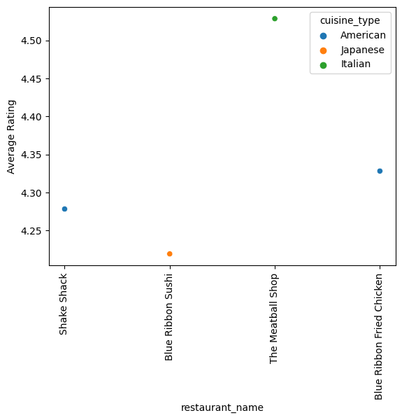

```python
sns.scatterplot(data=restaurantmostorders[(restaurantmostorders["mean"]>=4) & (restaurantmostorders['count'] > 50)], x="restaurant_name", y="mean", hue="cuisine_type")
plt.xticks(rotation=90)
plt.ylabel('Average Rating')
```

### **Question 14:** The company charges the restaurant 25% on the orders having cost greater than 20 dollars and 15% on the orders having cost greater than 5 dollars. Find the net revenue generated by the company across all orders. [3 marks]

```python
def calculate_revenue(df):

    net_profit = (
        (df.loc[df['cost_of_the_order'] > 20.0, 'cost_of_the_order'] * 0.25).sum() +
        (df.loc[(df['cost_of_the_order'] > 5.0) & (df['cost_of_the_order'] <= 20.0), 'cost_of_the_order'] * 0.15).sum()
    )

    return net_profit
```

```python
netprofit = calculate_revenue(df)
netprofit
```

```
6166.303
```

#### Observations:

*The net profit generated by the company is 6166.303 dollars*

### **Question 15:** The company wants to analyze the total time required to deliver the food. What percentage of orders take more than 60 minutes to get delivered from the time the order is placed? (The food has to be prepared and then delivered.) [2 marks]

```python
(len(df[df['Total_Time_Taken'] > 60])/len(df)) * 100
```

```
10.537407797681771
```

#### Observations:

*10.53% of the orders take more than 60 minutes to be delivered to the customer.*

### **Question 16:** The company wants to analyze the delivery time of the orders on weekdays and weekends. How does the mean delivery time vary during weekdays and weekends? [2 marks]

```python
# Write the code here
df.groupby(['day_of_the_week'])['delivery_time'].mean()
```

```
day_of_the_week
Weekday   28.34
Weekend   22.47
Name: delivery_time, dtype: float64
```

#### Observations:

*During the weekday it takes 28.34 minutes and in the weekend it takes 22.47 minutes.*

### Few more observation

**Restaurants having good rating**

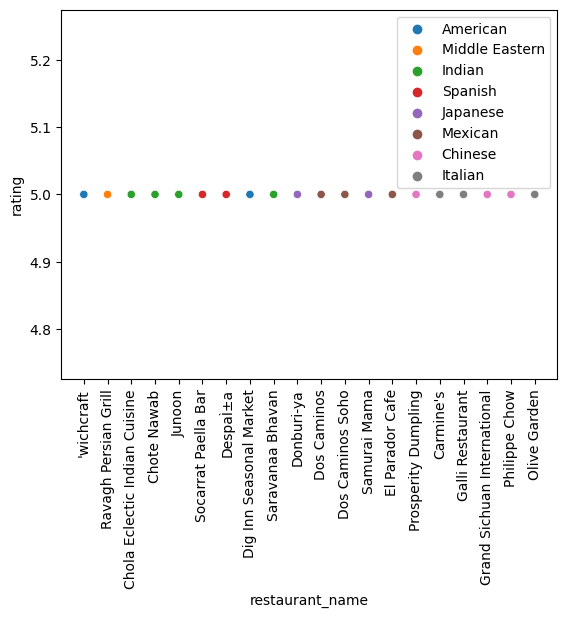

```python
highestratedrestaurtant = dfrated.groupby(["restaurant_name","cuisine_type"])["rating"].mean().reset_index().sort_values(ascending= False,by="rating")
sns.scatterplot(data=highestratedrestaurtant.head(20),x="restaurant_name",y="rating",hue="cuisine_type");
plt.xticks(rotation=90)
plt.legend(bbox_to_anchor=(1, 1))
```

### Recommendations:

- More Multi cuisine restaurant can be added to check whether is any impact on the customer satisfaction and rating.
- Ratings can be made mandatory to get a more precise customer's interest.